# Landscape Ecology Project draft

Mark Hill

10/31/2021

Warning: need Rtools to build packages, then run `sdm::installALL()` to make sure all the models are available

```r
options(java.parameters = "-Xmx8g")
```

We are going to use two different packages to execute the species distribution models: sdm and dismo

```r
library(dismo)
library(dplyr)
library(raster)
library(tidyverse)
library(maps)
library(maptools)
library(usdm)
library(sdm)
```

# Occurrence data

It is easy to gather occurrences right from R with `dismo::gbif()`. First we designate our area of interest so we don’t download a bazillion records. We are going to grab records for both species of Hemlock that grow on the east coast as they both are susceptible to the parasite of concern. These records are also filtered to include only geolocated human observations.

```r
ext <- extent(-85, -80, 34, 37)
tsuga <- gbif("Tsuga","canadensis",ext=ext,download=T, geo=T)
tsugaC <- gbif("Tsuga","caroliniana",ext=ext,download=T, geo=T)
tsuga <- bind_rows(tsuga,tsugaC)
tsuga <- filter(tsuga, basisOfRecord %in% c("HUMAN_OBSERVATION"))
tsuga <- select(tsuga,lon,lat)
tsuga$species <- 1
coordinates(tsuga) <- c("lon","lat")

rm(tsugaC)

adelges <- gbif("Adelges","tsugae", ext= ext, download= T, geo= T)
adelges <- filter(adelges, basisOfRecord %in% c("HUMAN_OBSERVATION"))
adelges <- select(adelges, lon, lat)
adelges$species <- 1
coordinates(adelges) <- c("lon", "lat")
```

This leaves us with a sufficient set of records for both the host and parasite.

```r
length(tsuga)
length(adelges)
```

```
## [1] 1104
## [1] 290
```

Before moving on we should take a peek to make sure they are where they should be.

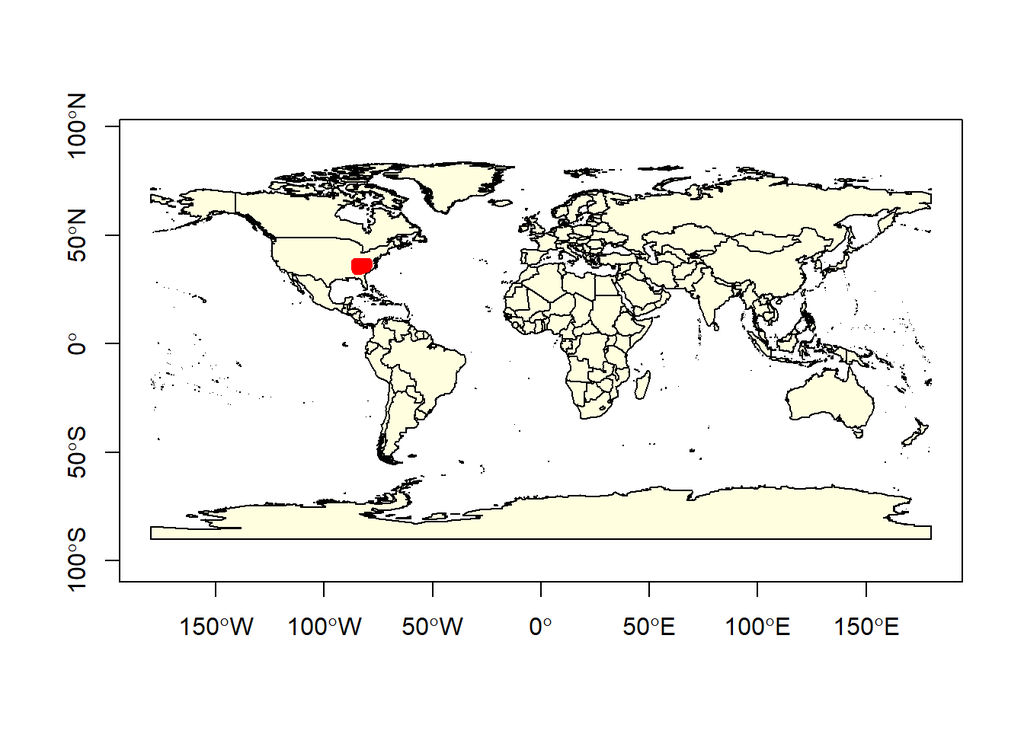

```r
data(wrld_simpl)
plot(wrld_simpl,
     #xlim=c(-100,-58), ylim=c(30,55),
     axes=TRUE, col="light yellow")
box()
points(tsuga, adelges, col= "red")
```

# Environmental predictors

As a start, I’ve included the bioclim variables, a digital elevation model, and two derived layers from the DEM: slope and aspect. Bioclim is rather straightforward but the DEM takes a little work to stitch the tiles together then crop to southern Appalachia aoi. Surely some of these tiles could be left off because they fall entirely outside the aoi.

### Climate

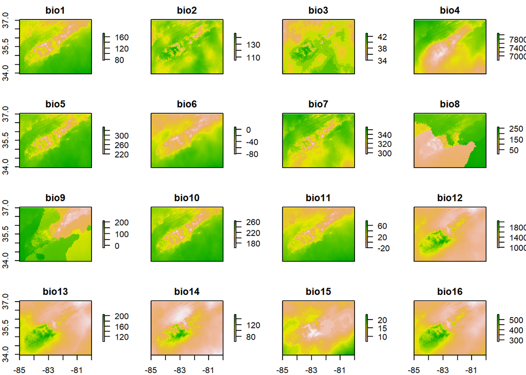

```r
clim_predictors <- raster::getData('worldclim', var='bio', res=2.5)
clim_predictors <- crop(clim_predictors, ext)
plot(clim_predictors)
```

### DEM

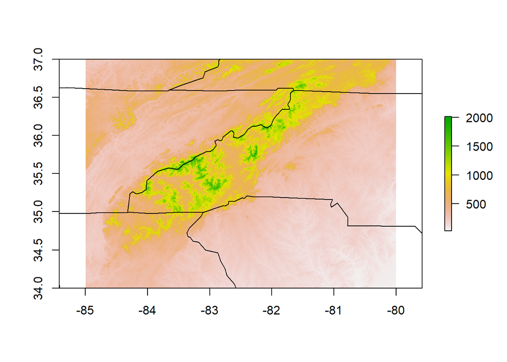

```r
topo0 <- raster::getData('SRTM', lon= -85, lat= 35)
topo1 <- raster::getData('SRTM', lon= -86, lat= 33)
topo2 <- raster::getData('SRTM', lon= -86, lat= 36)
topo3 <- raster::getData('SRTM', lon= -85, lat= 36)
topo4 <- raster::getData('SRTM', lon= -79, lat= 36)
topo5 <- raster::getData('SRTM', lon= -79, lat= 41)
topo6 <- raster::getData('SRTM', lon= -82, lat= 41)
topo7 <- raster::getData('SRTM', lon= -77, lat= 33)
topo8 <- raster::getData('SRTM', lon= -87, lat= 42)

DEM <- merge(topo0,topo1,topo2,topo3,topo4,topo5,topo6,topo7,topo8)

DEM <- crop(DEM, ext)
plot(DEM)
map('state', add=TRUE)
```

```r
#calculate aspect from DEM
DEM_asp <- terrain(DEM, opt= "aspect")
#calculate slope from DEM
DEM_slp <- terrain(DEM, opt= "slope")
```

This leaves us with layers of two different resolutions though. Enter `raster::resample`. I don’t really know if should be doing this differently (eg changing the bioclim to finer res while also changing DEM to more coarse and meet in the middle sort of). So, make sure the whole raster brick has the same resolution and slap it all together.

```r
predictors_DEMres <- resample(clim_predictors, DEM, method='bilinear')
predictors <- addLayer(predictors_DEMres, DEM, DEM_asp, DEM_slp)
names(predictors)[20] <- 'DEM'
```

Almost there! Since i sort of threw everything at wall to see what stuck with regard to predictors, we’ll use a helper function from `package::usdm` to sort any multicolinearity between our predictors as im using regression type analysis to create a habitat suitablity for the host species.

```r
locations <- raster::extract(predictors, tsuga)
v <- vifstep(locations)
predictors <- exclude(predictors,v)
```

`sdm::sdm` wants the data used in the model wrapped up in a special little package so there is one more step in data preparation.

```r
dat <- sdmData(species~., tsuga, predictors = predictors,
               bg = list(method= "gRandom", n= 999))
```

```
##            used  (Mb) gc trigger   (Mb)  max used   (Mb)
## Ncells  5086497 271.7    9548068  510.0   6926322  370.0
## Vcells 61376537 468.3  167220344 1275.8 167220344 1275.8
```

# Host model

Mostly for the sake of this not taking FOREVER I’m gonna run the more simple algorithms a few times then stitch them together to create our input for parasite analysis. Which methods to use should be revisited and considered more carefully.

```r
system.time(
  {model <- sdm(species~., dat, methods = c("glm", "bioclim"),
             replication= 'sub', test.percent= 30, n=3,
             parallelSettings=list(ncore=10, method="parallel"))
              }
            )
```

```
##    user  system elapsed
##    0.69    0.12   10.86
```

```r
model
```

```
## class                                 : sdmModels
## ========================================================
## number of species                     :  1
## number of modelling methods           :  2
## names of modelling methods            :  glm, bioclim
## replicate.methods (data partitioning) :  subsampling
## number of replicates (each method)    :  3
## toral number of replicates per model  :  3 (per species)
## test percentage (in subsampling)      :  30
## ------------------------------------------
## model run success percentage (per species)  :
## ------------------------------------------
## method          species
## ----------------------
## glm        :        100   %
## bioclim    :        100   %
##
## ###################################################################
## model Mean performance (per species), using test dataset (generated using partitioning):
## -------------------------------------------------------------------------------
##
##  ## species   :  species
## =========================
##
## methods    :     AUC     |     COR     |     TSS     |     Deviance
## -------------------------------------------------------------------------
## glm        :     0.85    |     0.62    |     0.6     |     0.95
## bioclim    :     0.74    |     0.49    |     0.47    |     3.23
```

Then I’ll use the weighted average of these for later.

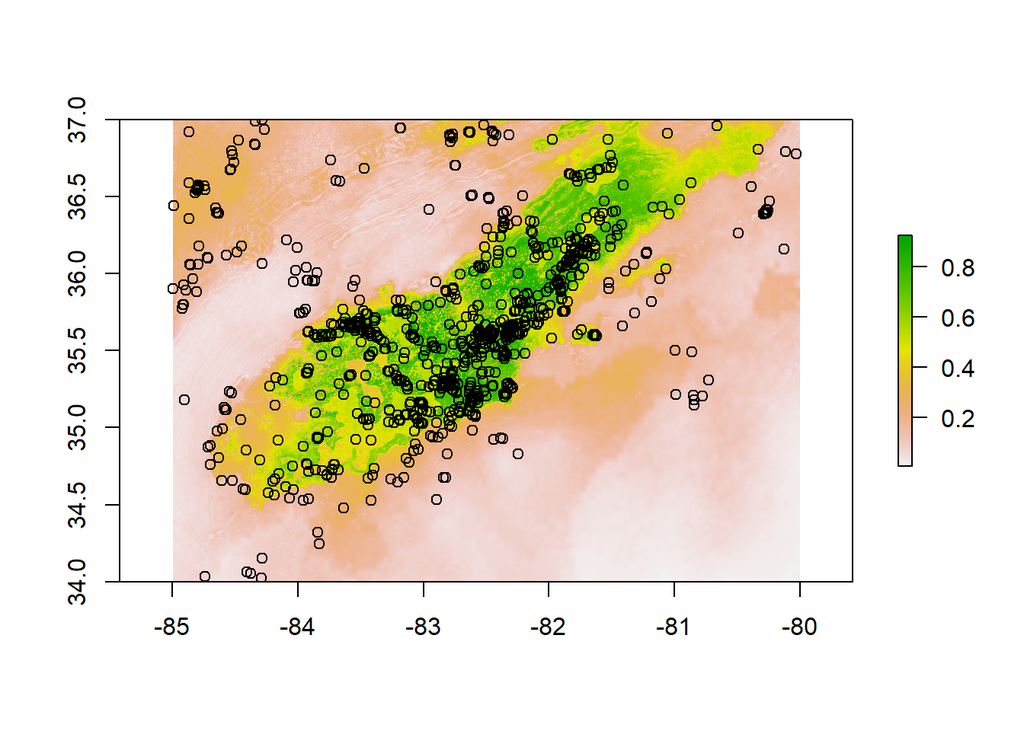

```
##    user  system elapsed
##  570.32   11.26  581.69
```

```r
system.time(
  {magic <- ensemble(model, predictors,
                  setting = list(method="weighted", stat="tss", opt=2)
                  )
  }
)


plot(magic)
points(tsuga)
```

# Target Species Model

First, we will start by adding the previously produced host probability surface to the predictors used in the adelgid model. Here we are still using the smaller predictor set, yet not using regression.. who? what you mean multicolinearity?

```r
adelgidpredictors <- addLayer(predictors, magic)
names(adelgidpredictors)[11] <- 'tsuga_ensemble'
```

```r
set.seed(1)

group <- kfold(adelges, 5)
pres_train <- adelges[group != 1, ]
pres_test <- adelges[group == 1, ]

backg_test <- randomPoints(adelgidpredictors, n=500, ext=ext, extf = 1.25)
colnames(backg_test) = c('lon', 'lat')
```

### Get ’er done!

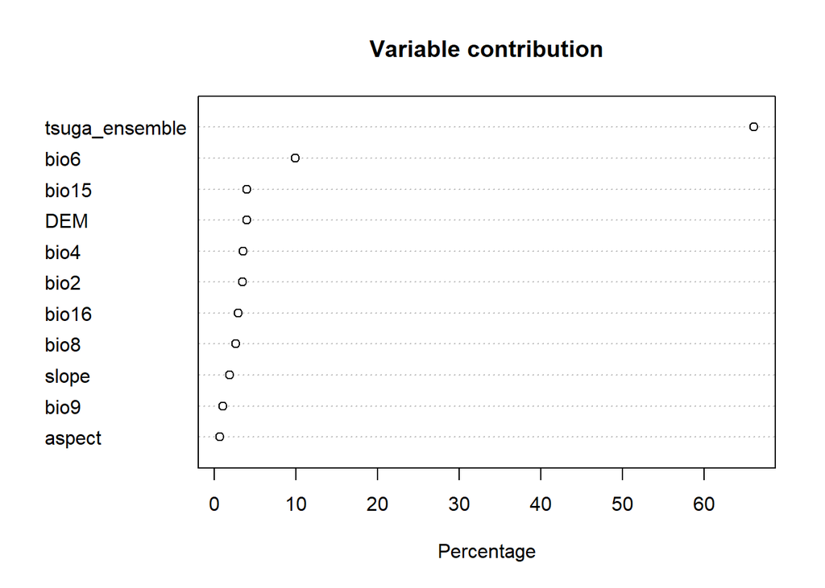

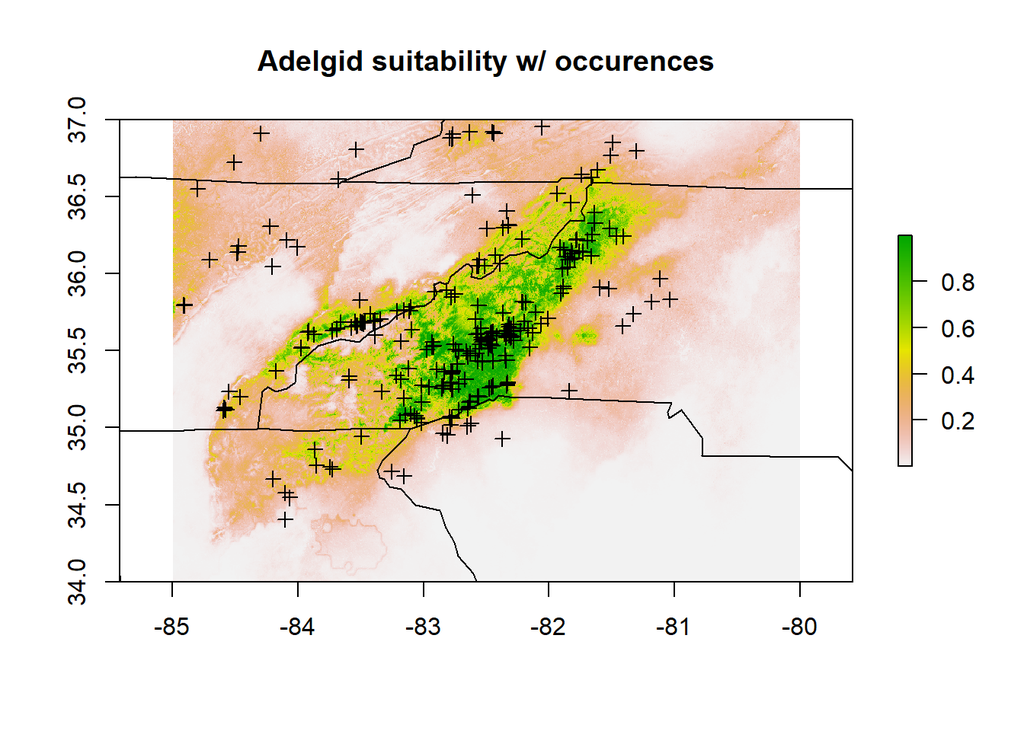

```
## This is MaxEnt version 3.4.3
##    user  system elapsed
## 1678.11    7.11 1667.23
```

```r
system.time(
  {adelgidmodel <- dismo::maxent(adelgidpredictors, pres_train)

adelgidmodel
plot(adelgidmodel)

adelgidsuitability <- predict(adelgidmodel, adelgidpredictors)

#writeRaster(adelgidsuitability, "adelgidSuitability", overwrite=TRUE)


plot(adelgidsuitability)
points(adelges, pch=3)
map('state', add= TRUE)
title("Adelgid suitability w/ occurences")

  }
)
```